# Part I - (Données de prets de Prosper Exploration )

## Introduction

> Pour notre choix de dataset nous avons porté notre choix sur les données de prets de Prosper. cet ensemble de données contient 113 937 prêts avec 81 variables sur chaque prêt, y compris le montant du prêt, le taux de l'emprunteur (ou taux d'intérêt), le statut actuel du prêt, le revenu de l'emprunteur, et bien d'autres. Dans l'analyse de notre dataset nous chercherons à avoir plus ample connaissances de données , voir la distribution de nos variables mais aussi d'essayer de répondre aux questions suivantes nous appuyant sur nos données . Quels sont les acteurs qui influent sur l'état des résultats d'un prêt ? Qu'est-ce qui affecte le TAP ou le taux d'intérêt de l'emprunteur ? Afin de connaitre nos données et répondre aux questions posées , parmi les 81 variables, nous choisirons 20 variables dont la liste est dréssée ci dessous contenant notre variable d'intéret BorrowerAPR et d'autres varibles qui selon nous seront intéressant pour nos recherches.

## Preliminary Wrangling

```python
# importez tous les packages et définissez les tracés à intégrer en ligne
import numpy as np
import pandas as pd
import matplotlib.pyplot as plt
import seaborn as sb
%matplotlib inline
```

> Chargeons de notre jeu de données et décrivons les propriétés à travers les questions ci-dessous. Essayons de motiver nos objectifs d'exploration à travers cette section.

```python
# lisons notre fichier CSV
loan = pd.read_csv('prosperLoanData.csv')
```

```python
## imprimons le nombre de lignes et colonne de notre dataFramme
# imprimons les types des variables de notre dataframme
print(loan.shape)
print(loan.dtypes)
```

```
(113937, 81)
ListingKey                              object
ListingNumber                            int64
ListingCreationDate                     object
CreditGrade                             object
Term                                     int64
LoanStatus                              object
ClosedDate                              object
BorrowerAPR                            float64
BorrowerRate                           float64
LenderYield                            float64
EstimatedEffectiveYield                float64
EstimatedLoss                          float64
EstimatedReturn                        float64
ProsperRating (numeric)                float64
ProsperRating (Alpha)                   object
ProsperScore                           float64
ListingCategory (numeric)                int64
BorrowerState                           object
Occupation                              object
EmploymentStatus                        object
EmploymentStatusDuration               float64
IsBorrowerHomeowner                       bool
CurrentlyInGroup                          bool
GroupKey                                object
DateCreditPulled                        object
CreditScoreRangeLower                  float64
CreditScoreRangeUpper                  float64
FirstRecordedCreditLine                 object
CurrentCreditLines                     float64
OpenCreditLines                        float64
                                        ...
TotalProsperLoans                      float64
TotalProsperPaymentsBilled             float64
OnTimeProsperPayments                  float64
ProsperPaymentsLessThanOneMonthLate    float64
ProsperPaymentsOneMonthPlusLate        float64
ProsperPrincipalBorrowed               float64
ProsperPrincipalOutstanding            float64
ScorexChangeAtTimeOfListing            float64
```

[output cut: 8 more lines]

```
MonthlyLoanPayment                     float64
LP_CustomerPayments                    float64
LP_CustomerPrincipalPayments           float64
LP_InterestandFees                     float64
LP_ServiceFees                         float64
LP_CollectionFees                      float64
LP_GrossPrincipalLoss                  float64
LP_NetPrincipalLoss                    float64
LP_NonPrincipalRecoverypayments        float64
PercentFunded                          float64
Recommendations                          int64
InvestmentFromFriendsCount               int64
InvestmentFromFriendsAmount            float64
Investors                                int64
Length: 81, dtype: object
```

```python
# inspectons notre dataframme
loan.head(10)
```

|  | ListingKey | ListingNumber | ListingCreationDate | CreditGrade | Term | LoanStatus | ClosedDate | BorrowerAPR | BorrowerRate | LenderYield | ... | LP_ServiceFees | LP_CollectionFees | LP_GrossPrincipalLoss | LP_NetPrincipalLoss | LP_NonPrincipalRecoverypayments | PercentFunded | Recommendations | InvestmentFromFriendsCount | InvestmentFromFriendsAmount | Investors |
| --- | --- | --- | --- | --- | --- | --- | --- | --- | --- | --- | --- | --- | --- | --- | --- | --- | --- | --- | --- | --- | --- |
| 0 | 1021339766868145413AB3B | 193129 | 2007-08-26 19:09:29.263000000 | C | 36 | Completed | 2009-08-14 00:00:00 | 0.16516 | 0.1580 | 0.1380 | ... | -133.18 | 0.0 | 0.0 | 0.0 | 0.0 | 1.0 | 0 | 0 | 0.0 | 258 |
| 1 | 10273602499503308B223C1 | 1209647 | 2014-02-27 08:28:07.900000000 | NaN | 36 | Current | NaN | 0.12016 | 0.0920 | 0.0820 | ... | 0.00 | 0.0 | 0.0 | 0.0 | 0.0 | 1.0 | 0 | 0 | 0.0 | 1 |
| 2 | 0EE9337825851032864889A | 81716 | 2007-01-05 15:00:47.090000000 | HR | 36 | Completed | 2009-12-17 00:00:00 | 0.28269 | 0.2750 | 0.2400 | ... | -24.20 | 0.0 | 0.0 | 0.0 | 0.0 | 1.0 | 0 | 0 | 0.0 | 41 |
| 3 | 0EF5356002482715299901A | 658116 | 2012-10-22 11:02:35.010000000 | NaN | 36 | Current | NaN | 0.12528 | 0.0974 | 0.0874 | ... | -108.01 | 0.0 | 0.0 | 0.0 | 0.0 | 1.0 | 0 | 0 | 0.0 | 158 |
| 4 | 0F023589499656230C5E3E2 | 909464 | 2013-09-14 18:38:39.097000000 | NaN | 36 | Current | NaN | 0.24614 | 0.2085 | 0.1985 | ... | -60.27 | 0.0 | 0.0 | 0.0 | 0.0 | 1.0 | 0 | 0 | 0.0 | 20 |
| 5 | 0F05359734824199381F61D | 1074836 | 2013-12-14 08:26:37.093000000 | NaN | 60 | Current | NaN | 0.15425 | 0.1314 | 0.1214 | ... | -25.33 | 0.0 | 0.0 | 0.0 | 0.0 | 1.0 | 0 | 0 | 0.0 | 1 |
| 6 | 0F0A3576754255009D63151 | 750899 | 2013-04-12 09:52:56.147000000 | NaN | 36 | Current | NaN | 0.31032 | 0.2712 | 0.2612 | ... | -22.95 | 0.0 | 0.0 | 0.0 | 0.0 | 1.0 | 0 | 0 | 0.0 | 1 |
| 7 | 0F1035772717087366F9EA7 | 768193 | 2013-05-05 06:49:27.493000000 | NaN | 36 | Current | NaN | 0.23939 | 0.2019 | 0.1919 | ... | -69.21 | 0.0 | 0.0 | 0.0 | 0.0 | 1.0 | 0 | 0 | 0.0 | 1 |
| 8 | 0F043596202561788EA13D5 | 1023355 | 2013-12-02 10:43:39.117000000 | NaN | 36 | Current | NaN | 0.07620 | 0.0629 | 0.0529 | ... | -16.77 | 0.0 | 0.0 | 0.0 | 0.0 | 1.0 | 0 | 0 | 0.0 | 1 |
| 9 | 0F043596202561788EA13D5 | 1023355 | 2013-12-02 10:43:39.117000000 | NaN | 36 | Current | NaN | 0.07620 | 0.0629 | 0.0529 | ... | -16.77 | 0.0 | 0.0 | 0.0 | 0.0 | 1.0 | 0 | 0 | 0.0 | 1 |

10 rows × 81 columns

```python
# donnons la description statistique des variables numériques
loan.describe()
```

|  | ListingNumber | Term | BorrowerAPR | BorrowerRate | LenderYield | EstimatedEffectiveYield | EstimatedLoss | EstimatedReturn | ProsperRating (numeric) | ProsperScore | ... | LP_ServiceFees | LP_CollectionFees | LP_GrossPrincipalLoss | LP_NetPrincipalLoss | LP_NonPrincipalRecoverypayments | PercentFunded | Recommendations | InvestmentFromFriendsCount | InvestmentFromFriendsAmount | Investors |
| --- | --- | --- | --- | --- | --- | --- | --- | --- | --- | --- | --- | --- | --- | --- | --- | --- | --- | --- | --- | --- | --- |
| count | 1.139370e+05 | 113937.000000 | 113912.000000 | 113937.000000 | 113937.000000 | 84853.000000 | 84853.000000 | 84853.000000 | 84853.000000 | 84853.000000 | ... | 113937.000000 | 113937.000000 | 113937.000000 | 113937.000000 | 113937.000000 | 113937.000000 | 113937.000000 | 113937.000000 | 113937.000000 | 113937.000000 |
| mean | 6.278857e+05 | 40.830248 | 0.218828 | 0.192764 | 0.182701 | 0.168661 | 0.080306 | 0.096068 | 4.072243 | 5.950067 | ... | -54.725641 | -14.242698 | 700.446342 | 681.420499 | 25.142686 | 0.998584 | 0.048027 | 0.023460 | 16.550751 | 80.475228 |
| std | 3.280762e+05 | 10.436212 | 0.080364 | 0.074818 | 0.074516 | 0.068467 | 0.046764 | 0.030403 | 1.673227 | 2.376501 | ... | 60.675425 | 109.232758 | 2388.513831 | 2357.167068 | 275.657937 | 0.017919 | 0.332353 | 0.232412 | 294.545422 | 103.239020 |
| min | 4.000000e+00 | 12.000000 | 0.006530 | 0.000000 | -0.010000 | -0.182700 | 0.004900 | -0.182700 | 1.000000 | 1.000000 | ... | -664.870000 | -9274.750000 | -94.200000 | -954.550000 | 0.000000 | 0.700000 | 0.000000 | 0.000000 | 0.000000 | 1.000000 |
| 25% | 4.009190e+05 | 36.000000 | 0.156290 | 0.134000 | 0.124200 | 0.115670 | 0.042400 | 0.074080 | 3.000000 | 4.000000 | ... | -73.180000 | 0.000000 | 0.000000 | 0.000000 | 0.000000 | 1.000000 | 0.000000 | 0.000000 | 0.000000 | 2.000000 |
| 50% | 6.005540e+05 | 36.000000 | 0.209760 | 0.184000 | 0.173000 | 0.161500 | 0.072400 | 0.091700 | 4.000000 | 6.000000 | ... | -34.440000 | 0.000000 | 0.000000 | 0.000000 | 0.000000 | 1.000000 | 0.000000 | 0.000000 | 0.000000 | 44.000000 |
| 75% | 8.926340e+05 | 36.000000 | 0.283810 | 0.250000 | 0.240000 | 0.224300 | 0.112000 | 0.116600 | 5.000000 | 8.000000 | ... | -13.920000 | 0.000000 | 0.000000 | 0.000000 | 0.000000 | 1.000000 | 0.000000 | 0.000000 | 0.000000 | 115.000000 |
| max | 1.255725e+06 | 60.000000 | 0.512290 | 0.497500 | 0.492500 | 0.319900 | 0.366000 | 0.283700 | 7.000000 | 11.000000 | ... | 32.060000 | 0.000000 | 25000.000000 | 25000.000000 | 21117.900000 | 1.012500 | 39.000000 | 33.000000 | 25000.000000 | 1189.000000 |

8 rows × 61 columns

> Notre dataset est trop volumineux , elle contient 81 colonnes or toutes les colonnes ne seront pas forcément utiles pour nos recherches , de ce fait nous allons réduire les colonnes de notre dataset selon nos besoins de recherche . Aussi nous travaillerons avec une copie de notre dataset pour ne pas nuire à son intégrité .

```python
# Nous avons créer une copie de notre dataframme que nous utiliserons
cp = loan.copy()
cp.head()
```

|  | ListingKey | ListingNumber | ListingCreationDate | CreditGrade | Term | LoanStatus | ClosedDate | BorrowerAPR | BorrowerRate | LenderYield | ... | LP_ServiceFees | LP_CollectionFees | LP_GrossPrincipalLoss | LP_NetPrincipalLoss | LP_NonPrincipalRecoverypayments | PercentFunded | Recommendations | InvestmentFromFriendsCount | InvestmentFromFriendsAmount | Investors |
| --- | --- | --- | --- | --- | --- | --- | --- | --- | --- | --- | --- | --- | --- | --- | --- | --- | --- | --- | --- | --- | --- |
| 0 | 1021339766868145413AB3B | 193129 | 2007-08-26 19:09:29.263000000 | C | 36 | Completed | 2009-08-14 00:00:00 | 0.16516 | 0.1580 | 0.1380 | ... | -133.18 | 0.0 | 0.0 | 0.0 | 0.0 | 1.0 | 0 | 0 | 0.0 | 258 |
| 1 | 10273602499503308B223C1 | 1209647 | 2014-02-27 08:28:07.900000000 | NaN | 36 | Current | NaN | 0.12016 | 0.0920 | 0.0820 | ... | 0.00 | 0.0 | 0.0 | 0.0 | 0.0 | 1.0 | 0 | 0 | 0.0 | 1 |
| 2 | 0EE9337825851032864889A | 81716 | 2007-01-05 15:00:47.090000000 | HR | 36 | Completed | 2009-12-17 00:00:00 | 0.28269 | 0.2750 | 0.2400 | ... | -24.20 | 0.0 | 0.0 | 0.0 | 0.0 | 1.0 | 0 | 0 | 0.0 | 41 |
| 3 | 0EF5356002482715299901A | 658116 | 2012-10-22 11:02:35.010000000 | NaN | 36 | Current | NaN | 0.12528 | 0.0974 | 0.0874 | ... | -108.01 | 0.0 | 0.0 | 0.0 | 0.0 | 1.0 | 0 | 0 | 0.0 | 158 |
| 4 | 0F023589499656230C5E3E2 | 909464 | 2013-09-14 18:38:39.097000000 | NaN | 36 | Current | NaN | 0.24614 | 0.2085 | 0.1985 | ... | -60.27 | 0.0 | 0.0 | 0.0 | 0.0 | 1.0 | 0 | 0 | 0.0 | 20 |

5 rows × 81 columns

> Afin de connaitre nos données et répondre aux questions posées , parmi les 81 variables, nous choisirons 20 variables dont la liste est dréssée ci dessous contenant notre variable d'intéret BorrowerAPR et d'autres varibles qui selon nous seront intéressant pour nos recherches. **Voici la liste des colonnes que nous utliserons et leurs définitions**
> 1. ListingCreationDate : La date à laquelle la liste a été créée.
> 2. Term : La durée du prêt exprimée en mois.
> 3. LoanStatus : L'état actuel du prêt : Annulé, Remboursé, Terminé, En cours, En défaut, Paiement final en cours, En souffrance. Le statut PastDue sera accompagné d'un seau de délinquance.
> 4. ClosedDate : L'état actuel du prêt : Annulé, Remboursé, Terminé, En cours, En défaut, Paiement final en cours, En souffrance. Le statut PastDue sera accompagné d'un seau de délinquance.
> 5. BorrowerAPR : Le taux annuel effectif global (TAEG) de l'emprunteur pour le prêt.
> 6. LenderYield : Le prêteur rapporte le prêt. Le rendement du prêteur est égal au taux d'intérêt sur le prêt moins les frais de service.
> 7. BorrowerRate : Le taux d'intérêt de l'Emprunteur pour ce prêt.
> 8. ProsperRating (numeric) : La note Prosper attribuée au moment de la création de l'annonce : 0 - N/A, 1 - HR, 2 - E, 3 - D, 4 - C, 5 - B, 6 - A, 7 - AA. Applicable aux prêts émis après juillet 2009.
> 9. ProsperRating (Alpha) : La note Prosper attribuée au moment de la création de la liste entre AA et HR. Applicable aux prêts émis après juillet 2009.
> 10. ProsperScore : Un score de risque personnalisé construit à l'aide des données historiques de Prosper. Le score varie de 1 à 10, 10 étant le meilleur score de risque ou le score de risque le plus faible. Applicable aux prêts émis après juillet 2009.
> 11. BorrowerState : L'abréviation à deux lettres de l'état de l'adresse de l'emprunteur au moment de la création de l'annonce.
> 12. Occupation : La profession sélectionnée par l'emprunteur au moment de la création de l'annonce.
> 13. TotalProsperLoans : Nombre de prêts Prosper accordés à l'emprunteur au moment où il a créé cette liste. Cette valeur sera nulle si l'emprunteur n'a pas eu de prêts antérieurs.
> 14. AmountDelinquent : Dollars en souffrance au moment où le profil de crédit a été retiré.
> 15. IncomeRange : La fourchette de revenus de l'emprunteur au moment de la création de l'annonce.
> 16. MonthlyLoanPayment : La mensualité prévue du prêt.
> 17. LoanOriginalAmount : Le montant initial du prêt.
> 18. LP_ServiceFees : Frais de recouvrement cumulés payés par les investisseurs qui ont investi dans le prêt.
> 19. LoanOriginationDate : La date à laquelle le prêt a été émis.
> 20. Investors : Le nombre d'investisseurs qui ont financé le prêt.

```python
# Réduisons le nombre de colonnes de notre dataset à 20 colonnes
df_prosper = cp.loc[:,  ['ListingCreationDate','Term','LoanStatus' , 'ClosedDate',
                     'BorrowerAPR','LenderYield','BorrowerRate',
                     'ProsperRating (numeric)' ,'ProsperRating (Alpha)' ,
                     'ProsperScore', 'BorrowerState', 'Occupation',
                    'TotalProsperLoans', 'AmountDelinquent','IncomeRange','MonthlyLoanPayment'
                         ,'LoanOriginalAmount','LP_ServiceFees','LoanOriginationDate','Investors']]
df_prosper.info()
```

```
<class 'pandas.core.frame.DataFrame'>
RangeIndex: 113937 entries, 0 to 113936
Data columns (total 20 columns):
ListingCreationDate        113937 non-null object
Term                       113937 non-null int64
LoanStatus                 113937 non-null object
ClosedDate                 55089 non-null object
BorrowerAPR                113912 non-null float64
LenderYield                113937 non-null float64
BorrowerRate               113937 non-null float64
ProsperRating (numeric)    84853 non-null float64
ProsperRating (Alpha)      84853 non-null object
ProsperScore               84853 non-null float64
BorrowerState              108422 non-null object
Occupation                 110349 non-null object
TotalProsperLoans          22085 non-null float64
AmountDelinquent           106315 non-null float64
IncomeRange                113937 non-null object
MonthlyLoanPayment         113937 non-null float64
LoanOriginalAmount         113937 non-null int64
LP_ServiceFees             113937 non-null float64
LoanOriginationDate        113937 non-null object
Investors                  113937 non-null int64
dtypes: float64(9), int64(3), object(8)
memory usage: 17.4+ MB
```

```python
# inspectons notre nouvel dataframme
df_prosper.head(10)
```

|  | ListingCreationDate | Term | LoanStatus | ClosedDate | BorrowerAPR | LenderYield | BorrowerRate | ProsperRating (numeric) | ProsperRating (Alpha) | ProsperScore | BorrowerState | Occupation | TotalProsperLoans | AmountDelinquent | IncomeRange | MonthlyLoanPayment | LoanOriginalAmount | LP_ServiceFees | LoanOriginationDate | Investors |
| --- | --- | --- | --- | --- | --- | --- | --- | --- | --- | --- | --- | --- | --- | --- | --- | --- | --- | --- | --- | --- |
| 0 | 2007-08-26 19:09:29.263000000 | 36 | Completed | 2009-08-14 00:00:00 | 0.16516 | 0.1380 | 0.1580 | NaN | NaN | NaN | CO | Other | NaN | 472.0 | $25,000-49,999 | 330.43 | 9425 | -133.18 | 2007-09-12 00:00:00 | 258 |
| 1 | 2014-02-27 08:28:07.900000000 | 36 | Current | NaN | 0.12016 | 0.0820 | 0.0920 | 6.0 | A | 7.0 | CO | Professional | NaN | 0.0 | $50,000-74,999 | 318.93 | 10000 | 0.00 | 2014-03-03 00:00:00 | 1 |
| 2 | 2007-01-05 15:00:47.090000000 | 36 | Completed | 2009-12-17 00:00:00 | 0.28269 | 0.2400 | 0.2750 | NaN | NaN | NaN | GA | Other | NaN | NaN | Not displayed | 123.32 | 3001 | -24.20 | 2007-01-17 00:00:00 | 41 |
| 3 | 2012-10-22 11:02:35.010000000 | 36 | Current | NaN | 0.12528 | 0.0874 | 0.0974 | 6.0 | A | 9.0 | GA | Skilled Labor | NaN | 10056.0 | $25,000-49,999 | 321.45 | 10000 | -108.01 | 2012-11-01 00:00:00 | 158 |
| 4 | 2013-09-14 18:38:39.097000000 | 36 | Current | NaN | 0.24614 | 0.1985 | 0.2085 | 3.0 | D | 4.0 | MN | Executive | 1.0 | 0.0 | $100,000+ | 563.97 | 15000 | -60.27 | 2013-09-20 00:00:00 | 20 |
| 5 | 2013-12-14 08:26:37.093000000 | 60 | Current | NaN | 0.15425 | 0.1214 | 0.1314 | 5.0 | B | 10.0 | NM | Professional | NaN | 0.0 | $100,000+ | 342.37 | 15000 | -25.33 | 2013-12-24 00:00:00 | 1 |
| 6 | 2013-04-12 09:52:56.147000000 | 36 | Current | NaN | 0.31032 | 0.2612 | 0.2712 | 2.0 | E | 2.0 | KS | Sales - Retail | NaN | 0.0 | $25,000-49,999 | 122.67 | 3000 | -22.95 | 2013-04-18 00:00:00 | 1 |
| 7 | 2013-05-05 06:49:27.493000000 | 36 | Current | NaN | 0.23939 | 0.1919 | 0.2019 | 4.0 | C | 4.0 | CA | Laborer | NaN | 0.0 | $25,000-49,999 | 372.60 | 10000 | -69.21 | 2013-05-13 00:00:00 | 1 |
| 8 | 2013-12-02 10:43:39.117000000 | 36 | Current | NaN | 0.07620 | 0.0529 | 0.0629 | 7.0 | AA | 9.0 | IL | Food Service | NaN | 0.0 | $25,000-49,999 | 305.54 | 10000 | -16.77 | 2013-12-12 00:00:00 | 1 |
| 9 | 2013-12-02 10:43:39.117000000 | 36 | Current | NaN | 0.07620 | 0.0529 | 0.0629 | 7.0 | AA | 11.0 | IL | Food Service | NaN | 0.0 | $25,000-49,999 | 305.54 | 10000 | -16.77 | 2013-12-12 00:00:00 | 1 |

```python
#listons les nombres de valeurs nulles dans les variables
df_prosper.isnull().sum()
```

```
ListingCreationDate            0
Term                           0
LoanStatus                     0
ClosedDate                 58848
BorrowerAPR                   25
LenderYield                    0
BorrowerRate                   0
ProsperRating (numeric)    29084
ProsperRating (Alpha)      29084
ProsperScore               29084
BorrowerState               5515
Occupation                  3588
TotalProsperLoans          91852
AmountDelinquent            7622
IncomeRange                    0
MonthlyLoanPayment             0
LoanOriginalAmount             0
LP_ServiceFees                 0
LoanOriginationDate            0
Investors                      0
dtype: int64
```

```python
# supprimmons les lignes contenant les valeurs nulles dans nos variables
df_prosper = df_prosper.dropna(subset=['ClosedDate','BorrowerAPR','ProsperRating (numeric)','ProsperRating (Alpha)',
     'ProsperScore','BorrowerState','Occupation','TotalProsperLoans','AmountDelinquent'])
df_prosper.isnull().sum()
```

```
ListingCreationDate        0
Term                       0
LoanStatus                 0
ClosedDate                 0
BorrowerAPR                0
LenderYield                0
BorrowerRate               0
ProsperRating (numeric)    0
ProsperRating (Alpha)      0
ProsperScore               0
BorrowerState              0
Occupation                 0
TotalProsperLoans          0
AmountDelinquent           0
IncomeRange                0
MonthlyLoanPayment         0
LoanOriginalAmount         0
LP_ServiceFees             0
LoanOriginationDate        0
Investors                  0
dtype: int64
```

```python
# informons nous une fois de plus sur notre dataframme
df_prosper.info()
```

```
<class 'pandas.core.frame.DataFrame'>
Int64Index: 8251 entries, 33 to 113935
Data columns (total 20 columns):
ListingCreationDate        8251 non-null object
Term                       8251 non-null int64
LoanStatus                 8251 non-null object
ClosedDate                 8251 non-null object
BorrowerAPR                8251 non-null float64
LenderYield                8251 non-null float64
BorrowerRate               8251 non-null float64
ProsperRating (numeric)    8251 non-null float64
ProsperRating (Alpha)      8251 non-null object
ProsperScore               8251 non-null float64
BorrowerState              8251 non-null object
Occupation                 8251 non-null object
TotalProsperLoans          8251 non-null float64
AmountDelinquent           8251 non-null float64
IncomeRange                8251 non-null object
MonthlyLoanPayment         8251 non-null float64
LoanOriginalAmount         8251 non-null int64
LP_ServiceFees             8251 non-null float64
LoanOriginationDate        8251 non-null object
Investors                  8251 non-null int64
dtypes: float64(9), int64(3), object(8)
memory usage: 1.3+ MB
```

```python
# voyons le nombre de valeurs dupliquées dans notre dataframme
df_prosper.duplicated().sum()
```

```
0
```

```python
# Ayons une vue d'ensemble  des valeurs de la variable ProsperRating (Alpha)
df_prosper['ProsperRating (Alpha)'].value_counts()
```

```
D     1715
A     1470
E     1438
C     1242
B      965
HR     941
AA     480
Name: ProsperRating (Alpha), dtype: int64
```

```python
# Renommons les variables ProsperRating (numeric) , ProsperRating (Alpha) pour moins
# d'encombrements
df_prosper = df_prosper.rename(columns={"ProsperRating (Alpha)": "ProsperRating _Alpha", "ProsperRating (numeric)": "ProsperRating_numeric"})
df_prosper.info()
```

```
<class 'pandas.core.frame.DataFrame'>
Int64Index: 8251 entries, 33 to 113935
Data columns (total 20 columns):
ListingCreationDate      8251 non-null object
Term                     8251 non-null int64
LoanStatus               8251 non-null object
ClosedDate               8251 non-null object
BorrowerAPR              8251 non-null float64
LenderYield              8251 non-null float64
BorrowerRate             8251 non-null float64
ProsperRating_numeric    8251 non-null float64
ProsperRating _Alpha     8251 non-null object
ProsperScore             8251 non-null float64
BorrowerState            8251 non-null object
Occupation               8251 non-null object
TotalProsperLoans        8251 non-null float64
AmountDelinquent         8251 non-null float64
IncomeRange              8251 non-null object
MonthlyLoanPayment       8251 non-null float64
LoanOriginalAmount       8251 non-null int64
LP_ServiceFees           8251 non-null float64
LoanOriginationDate      8251 non-null object
Investors                8251 non-null int64
dtypes: float64(9), int64(3), object(8)
memory usage: 1.3+ MB
```

> Convertissons certaines variables dates qui sont de types **string** (object) en type date , mais aussi certaines variables catégorielles en variables catégorielles ordinales.

```python
# convertissons ProsperRating(Alpha) ,IncomeRange en types de données catégoriques ordonnées
ordinal_var_dict = {'ProsperRating _Alpha': ['N/A','HR','E','D','C', 'B', 'A', 'AA'],
                    'IncomeRange': ['$0','$1-24,999','$25,000-49,999','$50,000-74,999','$75,000-99,999','$100,000+']}

for var in ordinal_var_dict:
    ordered_var = pd.api.types.CategoricalDtype(ordered = True,
                                                categories = ordinal_var_dict[var])
    df_prosper[var] = df_prosper[var].astype(ordered_var)
```

```python
# voici les nouveaux des variables de notre dataframme
df_prosper.dtypes
```

```
ListingCreationDate        object
Term                        int64
LoanStatus                 object
ClosedDate                 object
BorrowerAPR               float64
LenderYield               float64
BorrowerRate              float64
ProsperRating_numeric     float64
ProsperRating _Alpha     category
ProsperScore              float64
BorrowerState              object
Occupation                 object
TotalProsperLoans         float64
AmountDelinquent          float64
IncomeRange              category
MonthlyLoanPayment        float64
LoanOriginalAmount          int64
LP_ServiceFees            float64
LoanOriginationDate        object
Investors                   int64
dtype: object
```

```python
# Convertissons les variables ClosedDate , ListingCreationDate qui sont de type string en type date
df_prosper['ClosedDate'] = pd.to_datetime(df_prosper['ClosedDate'])
df_prosper['ListingCreationDate'] = pd.to_datetime(df_prosper['ListingCreationDate'])
df_prosper['LoanOriginationDate'] = pd.to_datetime(df_prosper['LoanOriginationDate'])

df_prosper.info()
```

```
<class 'pandas.core.frame.DataFrame'>
Int64Index: 8251 entries, 33 to 113935
Data columns (total 20 columns):
ListingCreationDate      8251 non-null datetime64[ns]
Term                     8251 non-null int64
LoanStatus               8251 non-null object
ClosedDate               8251 non-null datetime64[ns]
BorrowerAPR              8251 non-null float64
LenderYield              8251 non-null float64
BorrowerRate             8251 non-null float64
ProsperRating_numeric    8251 non-null float64
ProsperRating _Alpha     8251 non-null category
ProsperScore             8251 non-null float64
BorrowerState            8251 non-null object
Occupation               8251 non-null object
TotalProsperLoans        8251 non-null float64
AmountDelinquent         8251 non-null float64
IncomeRange              8187 non-null category
MonthlyLoanPayment       8251 non-null float64
LoanOriginalAmount       8251 non-null int64
LP_ServiceFees           8251 non-null float64
LoanOriginationDate      8251 non-null datetime64[ns]
Investors                8251 non-null int64
dtypes: category(2), datetime64[ns](3), float64(9), int64(3), object(3)
memory usage: 1.2+ MB
```

```python
# convertissons nos variables suivants en variables catégorielles
df_prosper['LoanStatus'] = df_prosper['LoanStatus'].astype('category')
df_prosper['BorrowerState'] = df_prosper['BorrowerState'].astype('category')
df_prosper['Occupation'] = df_prosper['Occupation'].astype('category')
df_prosper.dtypes
```

```
ListingCreationDate      datetime64[ns]
Term                              int64
LoanStatus                     category
ClosedDate               datetime64[ns]
BorrowerAPR                     float64
LenderYield                     float64
BorrowerRate                    float64
ProsperRating_numeric           float64
ProsperRating _Alpha           category
ProsperScore                    float64
BorrowerState                  category
Occupation                     category
TotalProsperLoans               float64
AmountDelinquent                float64
IncomeRange                    category
MonthlyLoanPayment              float64
LoanOriginalAmount                int64
LP_ServiceFees                  float64
LoanOriginationDate      datetime64[ns]
Investors                         int64
dtype: object
```

### Quelle est la structure de notre dataset?

> Notre dataset ProsperLoanData est composé de 113937 lignes et 81 colonnes , nous y avons pour le plus courant des variables quantitifs , nous avons aussi quelques variables qualitatifs qui ont été pour certains tranformés en variables catégoriels ordinaux et pour d'autres en variables catégoriels nominaux .

### Quelle(s) est/sont la/les principale(s) caractéristique(s) d'intérêt dans votre jeu de données ?

> Quels sont les acteurs qui influent sur l'état des résultats d'un prêt ?

> Qu'est-ce qui affecte le TAP ou le taux d'intérêt de l'emprunteur ?

### Selon vous, quelles fonctionnalités de l'ensemble de données vous aideront à étayer votre enquête sur les fonctionnalités qui vous intéressent ?

> Je pense que le statut de prêt et le AmountDeliquent(les dollars en souffrance) auront un impact considérable sur l'attribution des prêts et les interrogations que nous nous sommes posés . Le revenu mensuel et le prosperSore auront peut-etre leurs rôles à jouer ici .

## Univariate Exploration

> Dans cette section, étudiez les distributions des variables individuelles. Si vous voyez des points inhabituels ou des valeurs aberrantes, regardez de plus près pour nettoyer les choses et préparez-vous à examiner les relations entre les variables.

```python
# Création d'une fonction qui crée un graphique à barres pour une variable catégorielle
#univariée pour éviter de créer des codes de graphique à barres répétitifs.

def barchart(i):
    color=sb.color_palette()[0]
    sb.countplot(data = df_prosper, x= i, color=color);
def barcharty(i):
    color=sb.color_palette()[0]
    sb.countplot(data = df_prosper, y= i, color=color);
```

Comment est distribuée la variable Term en termes de mois ?

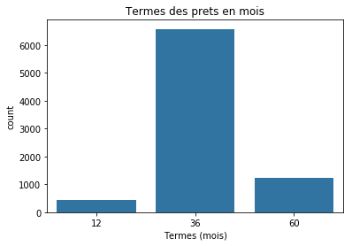

```python
#créons un diagramme à barre  pour regarder la distribution de la variable Term
barchart('Term')
plt.title('Termes des prets en mois')
plt.xlabel('Termes (mois)');
```

> la pluspart des prets arrivent à terme sur 36 mois(3 ans )

Quelle est la distribution des statuts de préts selon le nombre de prets ?

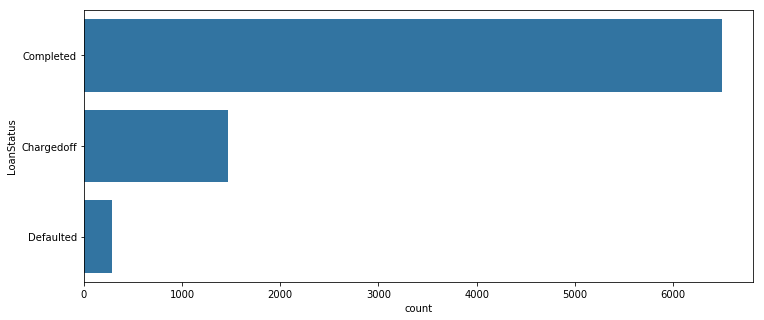

```python
# créons un histogramme pour réprésenter la variable LoanStatus
plt.figure(figsize = [12,5])
type_counts = df_prosper['LoanStatus'].value_counts()
type_order = type_counts.index
sb.countplot(data = df_prosper , y = 'LoanStatus' , color = base_color , order = type_order );
```

> on voit que la plupart des prets ont le statut **complété** c'est à dire , ont été remboursés

quelle est la distribution des rendements des preteurs sur le nombre total de prets ?

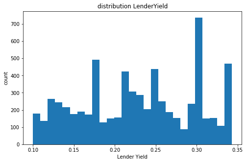

```python
# créons un histogramme pour réprésenter la variable Lenderyield
plt.figure(figsize = [8, 5])
bins = np.arange(0.1, df_prosper['LenderYield'].max()+0.009, 0.009)
plt.hist(data = df_prosper, x = 'LenderYield', bins = bins);
plt.xlabel('Lender Yield')
plt.title('distribution LenderYield')
plt.ylabel('count')
plt.show()
```

Quelle est la répartition des valeurs des montants originaux des prets ?

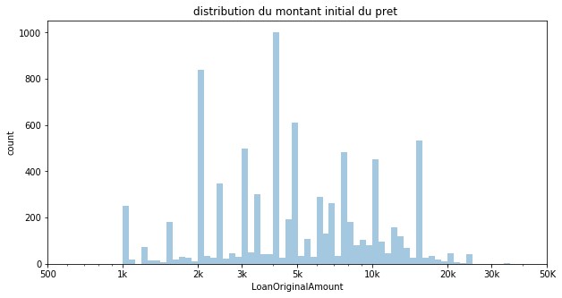

```python
# créons un histogramme pour réprésenter la variable LoanOriginalAmount
plt.figure(figsize = [10, 5])
log_binsize = 0.025
bins = 10 ** np.arange(3, np.log10(df_prosper['LoanOriginalAmount'].max())+log_binsize, log_binsize)
sb.distplot(df_prosper['LoanOriginalAmount'] , kde = False , bins = bins);
plt.xscale('log')
plt.title('distribution du montant initial du pret ');
plt.ylabel('count');
plt.xticks([500, 1e3, 2e3,3e3, 5e3, 1e4, 2e4, 3e4, 5e4], ['500', '1k', '2k', '3k', '5k', '10k', '20k', '30k', '50K']);
```

> La valeur la plus élevée pour le montant initial du prêt est entre 3000 et 5000 , il y'a aussi une valeur importante de pret pour le montant de 2000

Quelle est la répartition de la variable d'intéret BorrowerAPR sur les prets ?

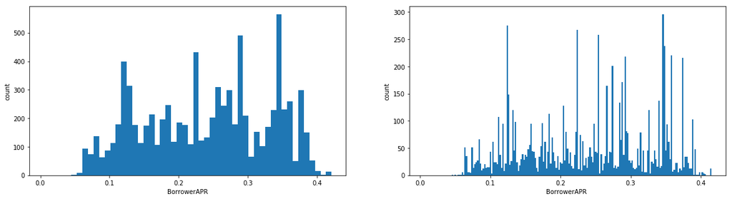

```python
# créons une distribution  pour réprésenter la variable d'intéret  BorrowerAPR
plt.figure(figsize=[20,5])
plt.subplot(1,2,1)
bins = np.arange(0.005, df_prosper['BorrowerAPR'].max()+0.008, 0.008)
plt.hist( df_prosper['BorrowerAPR'], bins = bins)
#plt.hist(data=df_prosper, x='BorrowerAPR', bins = bins)
plt.xlabel('BorrowerAPR')
plt.ylabel('count')

plt.subplot(1,2,2)
bins = np.arange(0.005, df_prosper['BorrowerAPR'].max()+0.002, 0.002)
#plt.hist(data=df_prosper, x='BorrowerAPR', bins = bins)
plt.hist( df_prosper['BorrowerAPR'], bins = bins)
plt.xlabel('BorrowerAPR ')
plt.ylabel('count')
plt.show();
```

> nous avons une distribution trimodale avec des pics de valeurs entre **0.1** et **0.2** , entre **0.2** et **0.3** et un pic plus élevé entre **0.3** et **0.4**

quelle est distribution du taux d'interet de l'emprunteur pour les prets ?

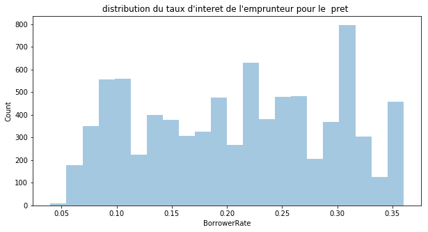

```python
# créons un histogramme pour réprésenter la variable BorrowerRate
plt.figure(figsize=[10,5])
sb.distplot(df_prosper['BorrowerRate'] , kde = False );
plt.title("distribution du taux d'interet de l'emprunteur pour le  pret ");
plt.ylabel('Count');
```

> le taux d'intéret le plus élevée est à 0.30

Quelle est la distribution des notes Prosper attribuées au moment de la création de l'annonce?

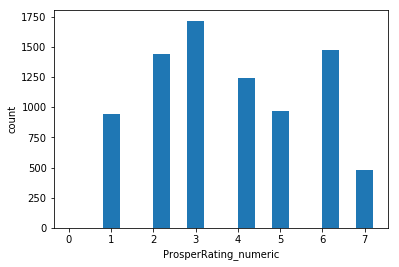

```python
# Distribution du ProsperRating_numeric
bins = np.arange(0, df_prosper['ProsperRating_numeric'].max()+ 0.4 , 0.4)
plt.hist( df_prosper['ProsperRating_numeric'], bins = bins)
plt.xlabel('ProsperRating_numeric')
plt.ylabel('count')
plt.show();
```

> la valeur la plus élévée du ProsperRating_numeric est à 3

Quelle est la distribution des notes Prosper attribuées au moment de la création de l'annonce émis après juillet 2009 ?

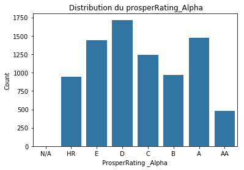

```python
plt.title(' Distribution du prosperRating_Alpha')
barchart('ProsperRating _Alpha')
plt.ylabel('Count');
```

> la valeur la plus élévée du ProsperRating_Alpha est à D

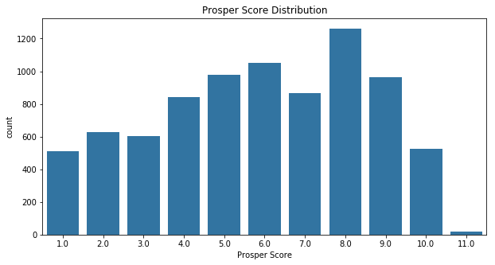

```python
plt.figure(figsize = [10,5])
barchart('ProsperScore')
plt.title('Prosper Score Distribution')
plt.xlabel('Prosper Score');
```

Comment est la répartition des lieux d'hatitats(états) des emprunteurs ?

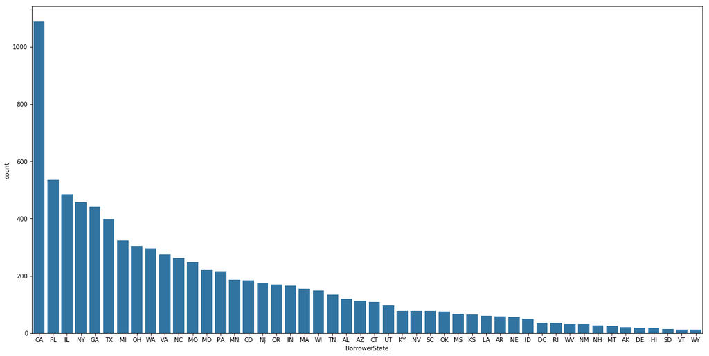

```python
type_counts = df_prosper['BorrowerState'].value_counts()
type_order = type_counts.index
plt.figure(figsize = [20,10])
sb.countplot(data = df_prosper , x ='BorrowerState' , color = base_color , order = type_order);
```

> la plus importante concentration du nombre de demandeurs de préts est en Californie suivi de la floride

Quelle est la distribution des occupations des emprunteurs?

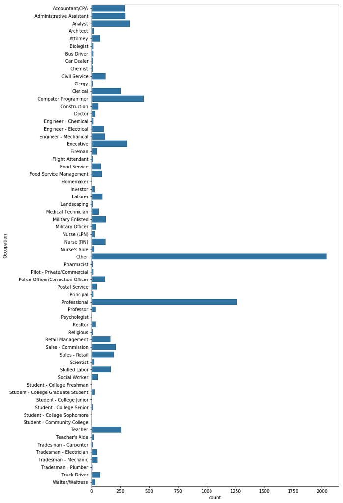

```python
plt.figure(figsize = [10,20])
barcharty('Occupation')
```

Comment est distribué les dollars en souffrance sur le total des emprunteurs ?

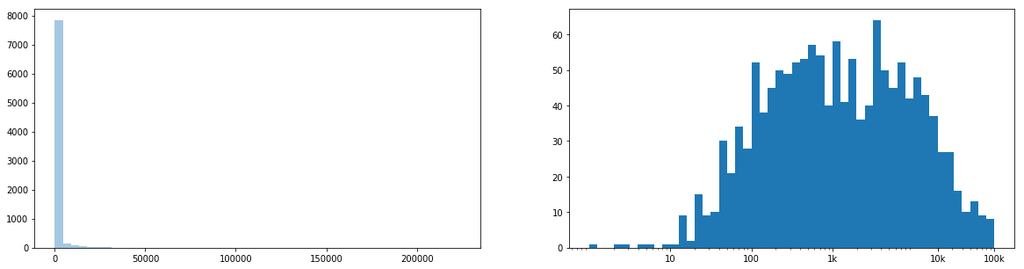

```python
# traçons l'histogramme de AmountDelinquent
plt.figure(figsize = [20,5])
plt.subplot(1,2,1)
sb.distplot(df_prosper['AmountDelinquent'].dropna().values , kde = False );
plt.subplot(1,2,2)
# Obtenir les ticks pour les cases entre [0 - maximum weight].
bins = 10 ** np.arange(0, 5+0.1, 0.1)
# Générer les x-ticks que vous voulez appliquer
#ticks = ['1','10', '100', '1k', '10k', '100k']
# Convertissez les ticks en valeurs de chaîne, à afficher sur l'axe des x
#labels = ['{}'.format(v) for v in ticks]
# Tracer l'histogramme
plt.hist(df_prosper['AmountDelinquent'], bins=bins);
# L'argument dans la fonction xscale() représente le type d'échelle d'axe à appliquer.
# Les valeurs possibles sont : {"linear", "log", "symlog", "logit", ...}
plt.xscale('log')
plt.xticks([1e1, 1e2, 1e3, 2e4, 1e5], ['10', '100', '1k', '10k', '100k']);
# Appliquer les x-ticks
#plt.xticks(ticks, labels);
```

```python
print(df_prosper['AmountDelinquent'].describe())
print(np.log10(df_prosper['AmountDelinquent'].describe()))
```

```
count      8251.000000
mean       1167.262029
std        7366.793497
min           0.000000
25%           0.000000
50%           0.000000
75%           0.000000
max      223738.000000
Name: AmountDelinquent, dtype: float64
count    3.916507
mean     3.067168
std      3.867278
min          -inf
25%          -inf
50%          -inf
75%          -inf
max      5.349740
Name: AmountDelinquent, dtype: float64
```

Quelle est la distribution des revenus annels des emprunteurs ?

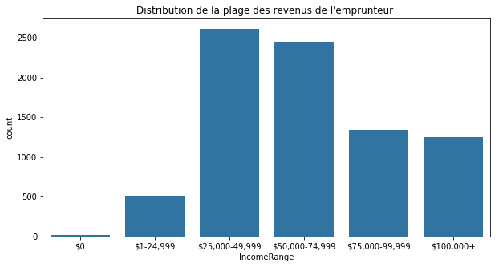

```python
# distribution des revenus  annels de l'emprunteur
plt.figure(figsize=[10, 5])
barchart('IncomeRange');
plt.title("Distribution de la plage des revenus de l'emprunteur ");
```

Quelle est la distribution de la plage des paiement mensuels des emprunteurs?

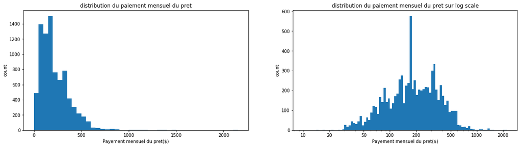

```python
# Monthly loan payment distribution
binsize = 50
bins = np.arange(0, df_prosper['MonthlyLoanPayment'].max()+binsize, binsize)
plt.figure(figsize=[20, 5])
plt.subplot(1,2,1)
plt.hist(data = df_prosper, x = 'MonthlyLoanPayment', bins = bins)
plt.xlabel('Payement mensuel du pret($)')
plt.ylabel('count')
plt.title('distribution du paiement mensuel du pret')
plt.subplot(1,2,2)
# Using log-scale
log_binsize = 0.025
bins_edges = 10 ** np.arange(1, np.log10(df_prosper['MonthlyLoanPayment'].max())+log_binsize, log_binsize)
plt.hist(data = df_prosper, x = 'MonthlyLoanPayment', bins = bins_edges)
plt.xscale('log')
plt.xticks([10, 20, 50, 100, 200, 500, 1e3, 2e3], ['10', '20','50', '100', '200', '500', '1000', '2000'])
plt.xlabel('Payement mensuel du pret($)')
plt.ylabel('count')
plt.title('distribution du paiement mensuel du pret sur log scale')
plt.show()
```

> le distribution de cette dernière est normale mais on a un pic de valeurs très élevé entre 100 et 200

Quelle est la distribution des frais de services sur l'ensemble des prets?

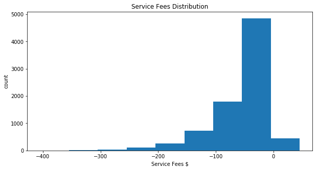

```python
# Service Fees Distribution
binsize = 50
bins = np.arange(df_prosper['LP_ServiceFees'].min(), df_prosper['LP_ServiceFees'].max()+binsize, binsize)

plt.figure(figsize=[10, 5])
plt.hist(data = df_prosper, x = 'LP_ServiceFees', bins = bins)
plt.xlabel('Service Fees $')
plt.title('Service Fees Distribution')
plt.ylabel('count')
plt.show()
```

> les services fees ne sont pas facilement interprétables en raison des valeurs négatives

Comment sont distribués les variables date de fermiture des prets , la date à laquelle la liste a été créée et la date à laquelle les prets ont émis ?

[figure not shown]

```python
plt.figure(figsize=[20,5])
plt.subplot(1,3,1)
sb.countplot(data=df_prosper,x=df_prosper['ClosedDate'].dt.year , color = base_color)
plt.title('Loans Originated by Year')
plt.xlabel('Loan Origination Year');

plt.subplot(1,3,2)
sb.countplot(data=df_prosper,x=df_prosper['ListingCreationDate'].dt.year,color=base_color)
plt.title('Loans Originated by Year')
plt.xlabel('Loan Origination Year');

plt.subplot(1,3,3)
sb.countplot(data=df_prosper,x=df_prosper['LoanOriginationDate'].dt.year,color=base_color)
plt.title('Loans Originated by Year')
plt.xlabel('Loan Origination Year');
```

### Of the features you investigated, were there any unusual distributions? Did you perform any operations on the data to tidy, adjust, or change the form of the data? If so, why did you do this?

> En raison de la grande différence entre les valeurs AmountDelinquent, la distribution était vraiment à grande échelle et je ne pouvais pas la voir clairement, j'ai donc effectué la transformation du journal. Certaines caractéristiques avaient des distributions asymétriques à longue queue, celles-ci ont été vérifiées sur une échelle logarithmique pour montrer la distribution cachée dans certaines zones.

## Bivariate Exploration

> Dans cette section, étudieons les relations entre les paires de variables dans notre Les données. Assurez-vous que les variables que nous couvrons ici ont été introduites dans certains mode dans la section précédente (exploration univariée). Pour commencer, je souhaite examiner les corrélations par paires présentes entre les caractéristiques des données.

```python
numeric_vars = ['Term','BorrowerAPR','LenderYield','BorrowerRate','ProsperRating_numeric','ProsperScore','TotalProsperLoans',
                 'AmountDelinquent','MonthlyLoanPayment','LP_ServiceFees','LoanOriginalAmount','Investors']
categorics_vars = ['LoanStatus' , 'IncomeRange','ProsperRating _Alpha','BorrowerState','Occupation',]
```

Existe t-il des relations entre les variables numériques ?

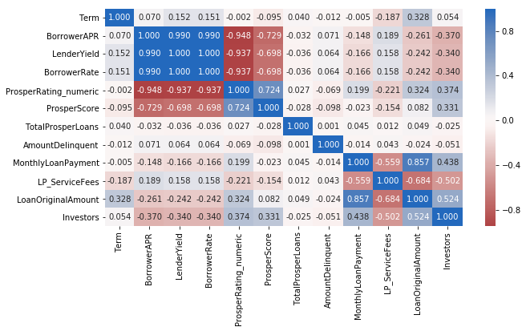

```python
# Matrice de corrélation pour les variables numériques
plt.figure(figsize = [10, 5])
sb.heatmap(df_prosper[numeric_vars].corr(), annot = True, fmt = '.3f',
           cmap = 'vlag_r', center = 0)
plt.show()
```

```
df_prosper.shape= (8251, 20)
df_prosper_samp.shape= (500, 20)
```

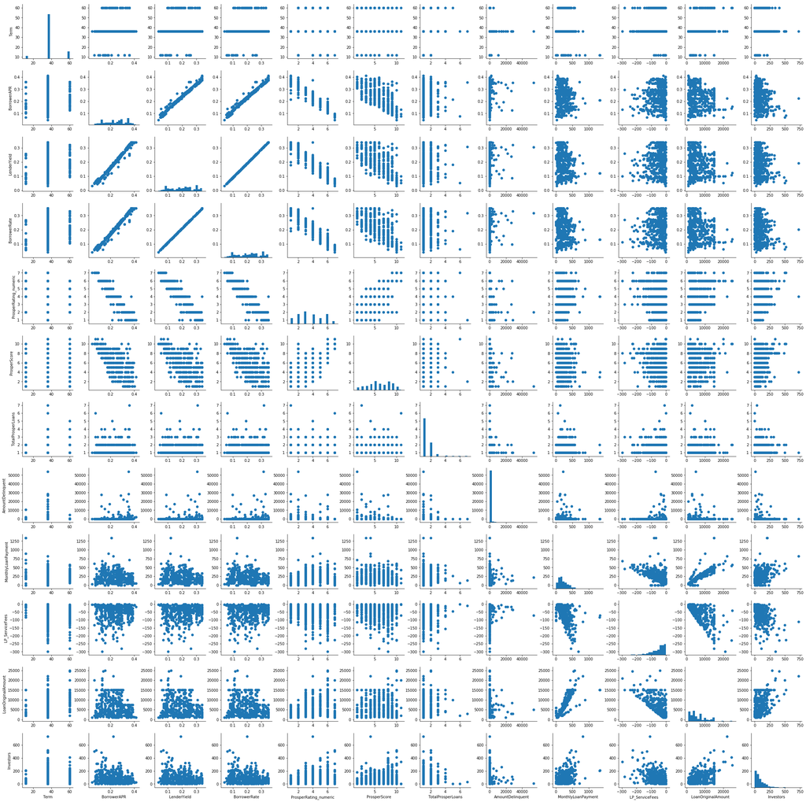

```python
# matrice de tracé : échantillonnez 500 préts pour que les tracés
#soient plus clairs et qu'ils s'affichent plus rapidement
print("df_prosper.shape=",df_prosper.shape)
df_prosper_samp = df_prosper.sample(n=500, replace = False)
print("df_prosper_samp.shape=",df_prosper_samp.shape)

g = sb.PairGrid(data = df_prosper_samp, vars = numeric_vars)
g = g.map_diag(plt.hist, bins = 20);
g.map_offdiag(plt.scatter)
```

> nous avons des corrélations positives entre le rendement du prêteur et le TAP de l'emprunteur. Prosper Score et Prosper Rating sont également une corrélation positive. Corrélation négative entre le score de prospérité et l'APR, et le score de prospérité et le rendement du prêteur. Corrélation négative entre les notes de prospérité et l'APR, et le score de prospérité et le rendement du prêteur.

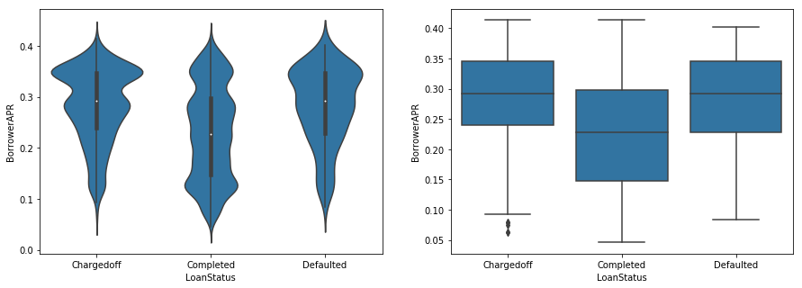

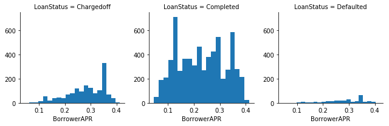

```python
#voir la  relation entre la  variable numérique d'intéret  BorrowerAPR et la variable  catégorielle LoanStatus
plt.figure(figsize = [15,5])
plt.subplot(1,2,1)
sb.violinplot(data = df_prosper , x = 'LoanStatus', y = 'BorrowerAPR' , color = base_color);
plt.subplot(1,2,2)
sb.boxplot(data = df_prosper , x = 'LoanStatus', y = 'BorrowerAPR' , color = base_color);
g = sb.FacetGrid(data = df_prosper , col = 'LoanStatus' );
g.map(plt.hist, 'BorrowerAPR', bins = 20);
```

> Sur le graphique BorrowerAPR vs LoanStatus, nous remarquons que les prêts achevés ont un taux APR inférieur à celui des prêts en souffrance.

Quelle est la relation qui existe qui existe entre la variable d'intéret BorrowerAPR et la variable ProsperRating _Alpha ?

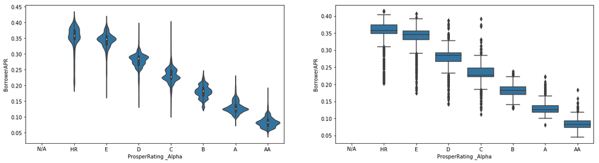

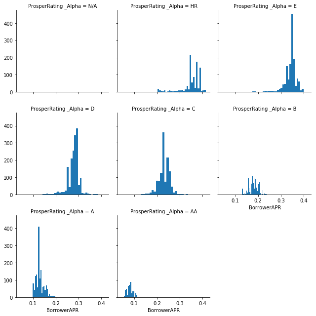

```python
plt.figure(figsize = [20,5])
plt.subplot(1,2,1)
sb.violinplot(data = df_prosper , x = 'ProsperRating _Alpha', y = 'BorrowerAPR' , color = base_color);
plt.subplot(1,2,2)
sb.boxplot(data = df_prosper , x = 'ProsperRating _Alpha', y = 'BorrowerAPR' , color = base_color);
g = sb.FacetGrid(data = df_prosper , col = 'ProsperRating _Alpha' , col_wrap = 3 )
g.map(plt.hist, 'BorrowerAPR', bins = 30)
```

> Sur le graphique BorrowerAPR vs ProsperRating_Alpha, nous remarquons que les emprunteurs avec un prosper_rating égale **AA** moins nombreux ont un taux APR plus bas contrairement à ceux ayant un prosper_rating égale à **E** ou à **HR** qui ont des taux APR élevés.

Quelle est la relation qui existe qui existe entre la variable d'intéret BorrowerAPR et la plage de salaire des emprunteurs ?

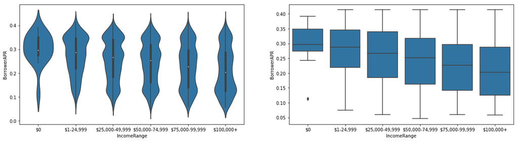

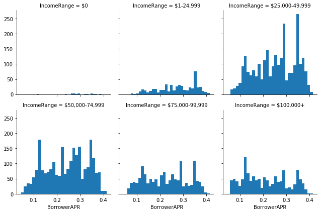

```python
plt.figure(figsize = [20,5])
plt.subplot(1,2,1)
sb.violinplot(data = df_prosper , x = 'IncomeRange', y = 'BorrowerAPR' , color = base_color);
plt.subplot(1,2,2)
sb.boxplot(data = df_prosper , x = 'IncomeRange', y = 'BorrowerAPR' , color = base_color);
g = sb.FacetGrid(data = df_prosper , col = 'IncomeRange' , col_wrap = 3 );
g.map(plt.hist, 'BorrowerAPR', bins = 30);
```

> Sur le graphique BorrowerAPR vs IncomeRange , nous remarquons que les emprunteurs avec aucun revenu ou des revenus entre 1 et 24,999 dollars ont des taux APR supérieurs aux autres avec , pour des emprunteurs avec aucun revenu les taux APR minimum commencent à peu près 0.24.

Quelle est la relation qui existe qui existe entre la variable d'intéret BorrowerAPR et l'état ou habite les emprunteurs ?

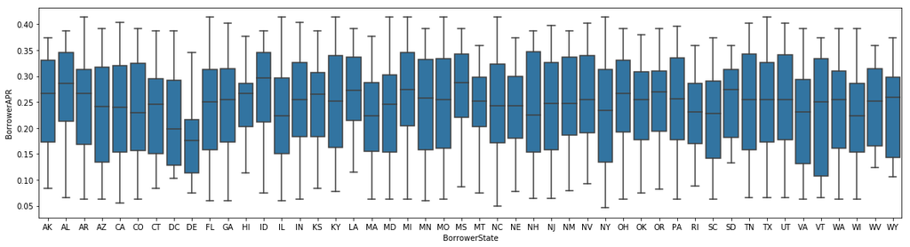

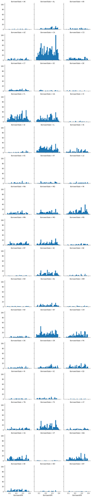

```python
plt.figure(figsize = [20,5])
sb.boxplot(data = df_prosper , x = 'BorrowerState', y = 'BorrowerAPR' , color = base_color);
g = sb.FacetGrid(data = df_prosper , col = 'BorrowerState' , col_wrap = 3 );
g.map(plt.hist, 'BorrowerAPR', bins = 30)
```

> on remarque qu'en général les emprunteurs habitant à **DE** : *Delaware* ont un taux d'APR beaucoup plus bas par rapport aux états

### Talk about some of the relationships you observed in this part of the investigation. How did the feature(s) of interest vary with other features in the dataset?

> Nous remarquons que les prêts achevés ont un taux APR inférieur à celui des prêts en souffrance , les emprunteurs avec un prosper_rating égale **AA** moins nombreux ont un taux APR plus bas contrairement à ceux ayant un prosper_rating égale à **E** ou à **HR** qui ont des taux APR élevés.On remarque aussi qu'en général les emprunteurs habitant à **DE** : *Delaware* ont un taux d'APR beaucoup plus bas par rapport aux états ; enfin les emprunteurs avec aucun revenu ou des revenus entre 1 et 24,999 achevés ont des taux APR supérieurs aux autres avec,pour des emprunteurs avec aucun revenu les taux APR minimum commencent à peu près 0.24.

### Did you observe any interesting relationships between the other features (not the main feature(s) of interest)?

> Les recherches ont été justes concentrées sur les variables d'intéret.

## Multivariate Exploration

> Créez des graphiques de trois variables ou plus pour étudier vos données même plus loin. Assurez-vous que vos investigations sont justifiées, et suivez votre travail dans les sections précédentes.

Quelle est la relation qui existe qui existe entre la variable d'intéret BorrowerAPR , la variable LenderYield et la variable AmountDelinquent ?

[figure not shown]

```python
plt.figure(figsize = [10, 5])
plt.scatter(data=df_prosper,x= 'BorrowerAPR',y='LenderYield', c='AmountDelinquent',cmap = 'viridis_r')
plt.colorbar(label = 'AmountDelinquent');
plt.title('LenderYield vs Borrower APR  vs ProsperRating');
plt.xlabel('Lender Yield');
plt.ylabel('Borrower APR');
```

Quelle est la relation qui existe qui existe entre la variable d'intéret BorrowerAPR , la variable IncomeRange et la variable LoanStatus?

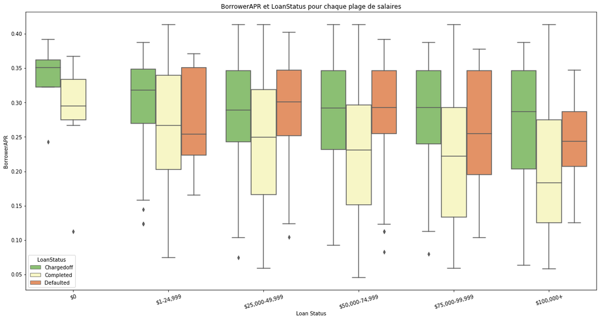

```python
# LoanStatus et  BorrowerAPR pour chaque plage de salaire
plt.figure(figsize=[20,10])
sb.boxplot(x="IncomeRange", y="BorrowerAPR", hue="LoanStatus", data=df_prosper, palette="RdYlGn_r");
plt.title('BorrowerAPR et LoanStatus pour chaque plage de salaires');
plt.xlabel('Loan Status');
plt.ylabel('BorrowerAPR');
plt.xticks(rotation = 15);
```

Quelle est la relation qui existe qui existe entre la variable d'intéret BorrowerAPR , la variable ProsperRating _Alpha et la variable LoanStatus?

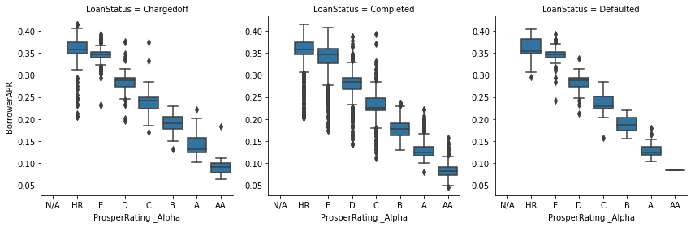

```python
plt.figure(figsize=[20,20])
g = sb.FacetGrid(data = df_prosper, col = 'LoanStatus' , size = 4 );
g.map(sb.boxplot, 'ProsperRating _Alpha', 'BorrowerAPR');
```

> Dans tous les loans status ceux qui ont les taux d'intéret les plus bas sont ceux qui un prosperRating_Alpha = AA , on remarque que le prosperRating joue un role essentielle sur le sur les taux d'intérets des prets plus plus prosperRating est bas plus le taux d'intérets est haut quelque soit le statut du Loan

### Were there any interesting or surprising interactions between features?

> il est surprenant de savoir que quelque soit le statut du Loan,on remarque que le prosperRating joue un role essentielle sur le sur les taux d'intérets des prets plus plus prosperRating est bas plus le taux d'intérets est haut .

## Conclusions

> Nous pouvons dire que aprés avoir lu , inpecté et nettoyé brièvement notre dataset ,les visualisations nous avons permis d'avoir plus ample connaissances sur nos données , révélant les relations entre les variables mais aussi plus connaissance des variables avec avec les différentes valeurs qui s'y trouvent et leurs distributions . Afin de répondre à nos questions posées , nous allons faire deuxième partie nous de visualisation descriptive